# ========================================

# **Unsupervised Learning Project**

# =========================================

## **Part A - 40 Marks**

## ==========================

**DOMAIN** : Business

**CASE STUDY** : Product Segmentation Case Study

**CONTEXT** : When you think of sneakers for a trip, the importance of good footwear cannot be discarded, and the obvious brands that come to mind are Adidas and Nike. Adidas vs Nike is a constant debate as the two giants in the apparel market, with a large market cap and market share, battle it out to come on top. As a newly hired Data Scientist in a market research company, you have been given the task of extracting insights from the data of men's and women's shoes, and grouping products together to identify similarities and differences between the product range of these renowned brands

**DATA DESCRIPTION** : The dataset consists of 3268 products from Nike and Adidas with features of information including their ratings, discount, sales price, listed price, product name, and the number of reviews.

- Product Name: Name of the product
- Product ID: ID of the product
- Listing Price: Listed price of the product
- Sale Price: Sale price of the product
- Discount: Percentage of discount on the product
- Brand: Brand of the product
- Rating: Rating of the product
- Reviews: Number of reviews for the product

**PROJECT OBJECTIVE**: To perform an exploratory data analysis and cluster the products based on various factors

## 1. Data Understanding:

### a. Read the Data set “data_add_nik.csv” and print the shape of the dataset. [2 marks]

```python
# Mounting Google Drive
from google.colab import drive
drive.mount('/content/drive')
```

```python
# Loading dataset from google drive
import pandas as pd

#Defining file path
file_path= '/content/drive/MyDrive/Colab_Notebooks/Unsupervised_Learning/data_add_nik.csv'

#Loading  dataset
df=pd.read_csv(file_path)

#Displaying first few rows
df.head()

#Displayng dataset shape
print("Dataset Shape:",df.shape)
```

```
Dataset Shape: (3268, 8)
```

### b. Check if there is any redundant column in the dataset and drop them. [1 mark]

```python
# Checking for redundant columns (columns with only one unique value)
redundant_columns = [col for col in df.columns if df[col].nunique() == 1]

# Dropping the redundant columns if we are finding any
if redundant_columns:
    df = df.drop(columns=redundant_columns)
    print("Dropping the redundant columns:", redundant_columns)
else:
    print("I am not finding any redundant columns.")
```

```
I am not finding any redundant columns.
```

### c. Check if there are any duplicate records in the dataset. If yes, drop them. [1 mark]

```python
# Checking for duplicate records in the DataFrame
duplicates = df.duplicated()

# Evaluating if we are finding any duplicate records
if duplicates.any():
    # Dropping duplicate records if we are finding any
    df = df.drop_duplicates()
    print("I am dropping duplicate records from the dataset.")
else:
    print("I did not find any duplicate records in the dataset.")
```

```
I did not find any duplicate records in the dataset.
```

### d. Check the 5 points summary of the whole data and share your observations. [1 mark]

```python
# Generating the 5 points summary of the dataset
summary = df.describe()
print(summary)
```

```
       Listing Price    Sale Price     Discount       Rating      Reviews
count    3180.000000   3180.000000  3180.000000  3180.000000  3180.000000
mean     6992.707547   6027.742767    27.619497     3.266635    41.529560
std      4677.133304   4192.481308    22.492385     1.393592    31.373989
min         0.000000    449.000000     0.000000     0.000000     0.000000
25%      4599.000000   2999.000000     0.000000     2.600000    12.000000
50%      5999.000000   4599.000000    40.000000     3.500000    39.000000
75%      8999.000000   7995.000000    50.000000     4.400000    69.000000
max     29999.000000  36500.000000    60.000000     5.000000   223.000000
```

## 2. **Exploratory Data Analysis:**

### a. Check how many products have Listing_price ‘0’. Check it’s 5 points summary and share your insights.

[2 marks]

```python
# Importing pandas as we are handling our dataset
import pandas as pd

# Filtering the dataset for products with a Listing Price of 0
zero_listing = df[df['Listing Price'] == 0]

# Printing the number of products with a Listing Price of 0
print("We are finding", len(zero_listing), "products with a Listing Price of 0.")

# Generating the 5-point summary for products with a Listing Price of 0
zero_listing_summary = zero_listing.describe()
print(zero_listing_summary)
```

```
We are finding 362 products with a Listing Price of 0.
       Listing Price    Sale Price  Discount      Rating     Reviews
count          362.0    362.000000     362.0  362.000000  362.000000
mean             0.0  11204.682320       0.0    2.678177    7.803867
std              0.0   4538.187946       0.0    2.187662   19.140614
min              0.0   1595.000000       0.0    0.000000    0.000000
25%              0.0   7995.000000       0.0    0.000000    0.000000
50%              0.0  10995.000000       0.0    3.800000    1.000000
75%              0.0  13995.000000       0.0    4.700000    6.000000
max              0.0  36500.000000       0.0    5.000000  223.000000
```

### **Sharing our insights:**

- We are observing that products with a Listing Price of 0 might be indicating missing data or data entry errors.
- We are considering that these entries may require further investigation or cleaning, as they might affect the overall analysis on product pricing.

### b. Records having Listing_price ‘0’, replace them with Sale_Price of that record. [2 marks]

```python
# Replacing records where the Listing Price is 0 with the corresponding Sale Price
df.loc[df['Listing Price'] == 0, 'Listing Price'] = df.loc[df['Listing Price'] == 0, 'Sale Price']

# Printing the count of records with Listing Price 0 after replacement to verify changes
zero_listing_after = df[df['Listing Price'] == 0]
print("We are finding", len(zero_listing_after), "records with a Listing Price of 0 after replacement.")
```

```
We are finding 0 records with a Listing Price of 0 after replacement.
```

### c. Check and print feature-wise percentage of missing values present in the data and impute with the best suitable approach. [2 Marks]

```python
# Calculating the feature-wise percentage of missing values
missing_percentage = df.isnull().mean() * 100
print("We are checking feature-wise missing percentages:")
print(missing_percentage)

# Imputing missing values if we are finding any
for col in df.columns:
    if df[col].isnull().sum() > 0:
        # Checking if the column is numerical
        if df[col].dtype in ['float64', 'int64']:
            # Using the median value for numerical features
            df[col].fillna(df[col].median(), inplace=True)
            print(f"We are imputing missing values in {col} with its median.")
        else:
            # Using the mode for categorical features
            df[col].fillna(df[col].mode()[0], inplace=True)
            print(f"We are imputing missing values in {col} with its mode.")

# Re-checking the feature-wise missing percentages after imputation
missing_percentage_after = df.isnull().mean() * 100
print("We are checking feature-wise missing percentages after imputation:")
print(missing_percentage_after)
```

```
We are checking feature-wise missing percentages:
Product Name     0.0
Product ID       0.0
Listing Price    0.0
Sale Price       0.0
Discount         0.0
Brand            0.0
Rating           0.0
Reviews          0.0
dtype: float64
We are checking feature-wise missing percentages after imputation:
Product Name     0.0
Product ID       0.0
Listing Price    0.0
Sale Price       0.0
Discount         0.0
Brand            0.0
Rating           0.0
Reviews          0.0
dtype: float64
```

### d. Perform univariate analysis on the data and share your insights. [ 2 marks ]

```
We are printing the summary statistics for numerical features:
       Listing Price    Sale Price     Discount       Rating      Reviews
count    3180.000000   3180.000000  3180.000000  3180.000000  3180.000000
mean     8268.209119   6027.742767    27.619497     3.266635    41.529560
std      4363.364929   4192.481308    22.492385     1.393592    31.373989
min       899.000000    449.000000     0.000000     0.000000     0.000000
25%      4999.000000   2999.000000     0.000000     2.600000    12.000000
50%      7599.000000   4599.000000    40.000000     3.500000    39.000000
75%     10995.000000   7995.000000    50.000000     4.400000    69.000000
max     36500.000000  36500.000000    60.000000     5.000000   223.000000
```

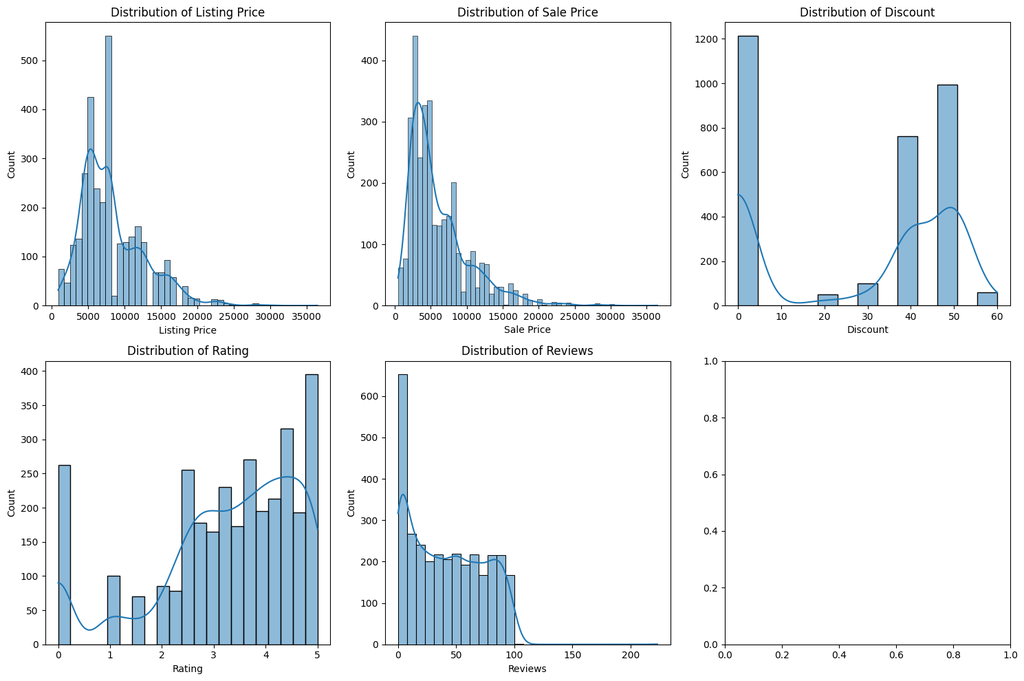

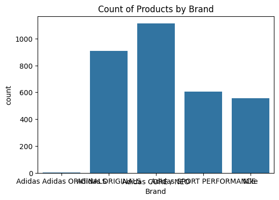

```python
# Importing the necessary libraries as we are handling our data analysis
import pandas as pd
import matplotlib.pyplot as plt
import seaborn as sns

# Performing univariate analysis on numerical features
numeric_features = ['Listing Price', 'Sale Price', 'Discount', 'Rating', 'Reviews']

# Printing the summary statistics for the numerical features
print("We are printing the summary statistics for numerical features:")
print(df[numeric_features].describe())

# Plotting histograms with KDE for each numerical feature
fig, axes = plt.subplots(2, 3, figsize=(15, 10))
axes = axes.flatten()

for i, feature in enumerate(numeric_features):
    sns.histplot(df[feature], kde=True, ax=axes[i])
    axes[i].set_title(f'Distribution of {feature}')

plt.tight_layout()
plt.show()

# Performing univariate analysis on the categorical feature 'Brand'
plt.figure(figsize=(6, 4))
sns.countplot(data=df, x='Brand')
plt.title("Count of Products by Brand")
plt.show()
```

### Below is a concise summary of insights from the **univariate analysis** of the key numerical features—**Listing Price**, **Sale Price**, **Discount**, **Rating**, and **Reviews**—based on the provided histograms and summary statistics:

### 1. Listing Price

- **Range**: 899 to 36,500
- **Mean**: 8,268 | **Median**: 7,599
- **Distribution**: Right-skewed (most products priced below ~15,000, with a few premium products reaching up to 36,500).
- **Insight**: The wide range suggests a diverse product lineup, from more affordable options to very high-end products.

### 2. Sale Price

- **Range**: 449 to 36,500
- **Mean**: 6,028 | **Median**: 4,599
- **Distribution**: Also right-skewed, but generally lower than Listing Price due to discounts.
- **Insight**: While some premium items remain expensive, most are sold in a mid-range bracket (~3,000–8,000).

### 4. Rating

- **Range**: 0 to 5
- **Mean**: 3.27 | **Median**: 3.5
- **Distribution**: Concentrated between 2.5 and 5, with a slight tail toward low ratings.
- **Insight**: Most products have moderate-to-high customer satisfaction (3+), though a small subset receives lower ratings (below 2).

### 5. Reviews

- **Range**: 0 to 223
- **Mean**: 41.5 | **Median**: 39
- **Distribution**: Right-skewed, indicating most products have fewer than 50 reviews, but some outliers have 100+ reviews.
- **Insight**: A few highly popular products garner a large share of reviews, while the majority remain less reviewed.

### Overall Observations

- **Price & Discount Relationship**: The right-skewed nature of both Listing Price and Sale Price suggests that while most products are in the lower-to-mid price range, there are premium products significantly above the median. The frequent discounts (40–50%) could be a strategic pricing approach to boost sales of higher-priced products.
- **Customer Engagement**: Ratings lean toward the higher end (3–5), and the reviews distribution indicates a handful of products attract much more attention than others.
- **Data Spread**: The large standard deviations in prices and reviews reflect a highly diverse product portfolio, appealing to various market segments.

### e. Perform bivariate and multivariate analysis and share your insights. [3 marks ]

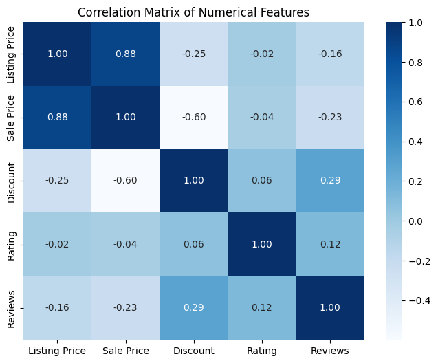

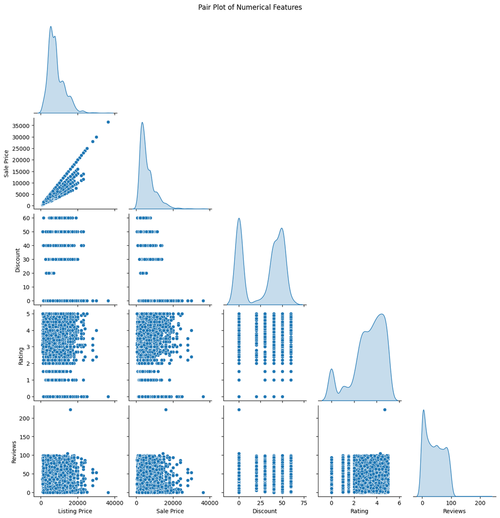

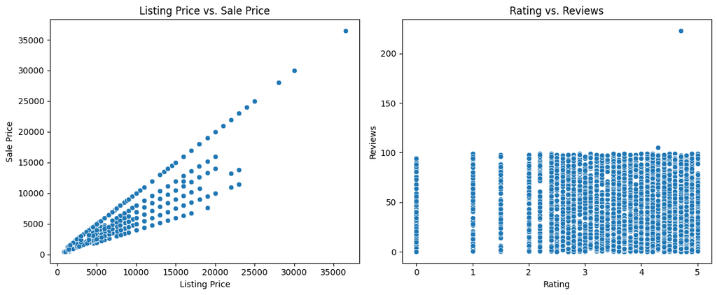

```python
# Selecting numerical features for bivariate and multivariate analysis
num_features = ['Listing Price', 'Sale Price', 'Discount', 'Rating', 'Reviews']

# -- BIVARIATE ANALYSIS USING CORRELATION MATRIX --

# We are computing the correlation matrix for the numerical features
corr_matrix = df[num_features].corr()

# We are plotting the correlation matrix as a heatmap
plt.figure(figsize=(8, 6))
sns.heatmap(corr_matrix, annot=True, cmap='Blues', fmt=".2f")
plt.title("Correlation Matrix of Numerical Features")
plt.show()

# -- MULTIVARIATE ANALYSIS USING PAIR PLOT --

# We are using a pair plot to visualize relationships among multiple features
sns.pairplot(df[num_features], corner=True, diag_kind='kde')
plt.suptitle("Pair Plot of Numerical Features", y=1.02)
plt.show()

# -- ADDITIONAL BIVARIATE ANALYSIS USING SCATTER PLOTS --

# We are creating two scatter plots to visualize specific relationships
fig, axes = plt.subplots(1, 2, figsize=(12, 5))

# Scatter plot for Listing Price vs Sale Price
sns.scatterplot(x='Listing Price', y='Sale Price', data=df, ax=axes[0])
axes[0].set_title("Listing Price vs. Sale Price")

# Scatter plot for Rating vs Reviews
sns.scatterplot(x='Rating', y='Reviews', data=df, ax=axes[1])
axes[1].set_title("Rating vs. Reviews")

plt.tight_layout()
plt.show()
```

## Below is a concise **bivariate and multivariate analysis** of the dataset, referencing the **correlation matrix**, **pair plots**, and **scatter plots** you provided.

### 1. Correlation Matrix

We are observing the following notable correlations:

1. **Listing Price vs. Sale Price**
   - High positive correlation (~0.88).
   - We are interpreting this to mean that higher-priced products (listing price) typically also have higher sale prices, even after discounts.
2. **Sale Price vs. Discount**
   - Strong negative correlation (~-0.60).
   - We are understanding that as the discount percentage goes up, the final sale price tends to go down (which aligns with how discounts work).
3. **Discount vs. Reviews**
   - Moderate positive correlation (~0.29).
   - We are suggesting that products with bigger discounts might attract more buyers, leading to more reviews—or possibly that popular products get featured with steeper discounts.
4. **Rating vs. Reviews**
   - Weak positive correlation (~0.12).
   - We are seeing that products with more reviews may have slightly higher ratings on average, but the relationship is not very strong.
5. **Rating vs. Price Variables**
   - Very weak correlation (near 0).
   - We are concluding that pricing has minimal direct influence on the product ratings.

### 2. Pair Plot

When we are examining the pair plot of the numerical features:

- **Listing Price & Sale Price**
  - The scatter plot reaffirms the strong positive relationship, showing an almost linear upward trend.
- **Discount**
  - We are noticing a clear split: many products have no discount (0%), while a significant cluster appears around 40–50%.
- **Rating & Reviews**
  - The distribution of ratings is centered between 3 and 4, with a smaller tail below 2.
  - Reviews are heavily right-skewed, indicating that a few products have exceptionally high numbers of reviews.

### 3. Scatter Plots

1. **Listing Price vs. Sale Price**
   - We are confirming a near-linear relationship, where higher listing prices correlate with higher sale prices.
   - A few high-end products (above ~30,000) stand out as outliers.
2. **Rating vs. Reviews**
   - We are seeing that some products with very high review counts also have high ratings, but many products with high ratings have relatively fewer reviews.
   - This suggests popularity (reviews) and satisfaction (rating) are not strictly tied to each other.

### 4. Overall Insights

- **Pricing Dynamics**
  - Listing Price and Sale Price are the most closely linked variables in the dataset.
  - Discounts strongly affect the sale price and may also influence product visibility (hence more reviews).
- **Customer Feedback**
  - Ratings and reviews do not strongly correlate with prices, suggesting that expensive or discounted products are not necessarily rated higher or lower.
  - The weak positive relationship between rating and reviews implies that while popular products might be somewhat more likely to have good ratings, many exceptions exist.
- **Strategic Considerations**
  - Brands could leverage discounts on higher-priced items to attract more reviews and potential buyers.
  - Ratings do not appear to depend heavily on price, so factors like product quality, style, or brand reputation may be more critical in driving customer satisfaction.

These findings give a clearer picture of how pricing, discounts, ratings, and reviews interact, offering valuable insights for product positioning, pricing strategies, and marketing campaigns.

## 3. Data Preprocessing :

### a. Scale all the numeric variables using suitable technique. [2 marks]

```python
# Importing the necessary libraries as we are performing our data preprocessing
from sklearn.preprocessing import StandardScaler

# Selecting the numeric columns we are going to scale
numeric_cols = ['Listing Price', 'Sale Price', 'Discount', 'Rating', 'Reviews']

# Creating an instance of StandardScaler
scaler = StandardScaler()

# Fitting the scaler on the numeric columns and transforming them
df[numeric_cols] = scaler.fit_transform(df[numeric_cols])

# Printing the first few rows of the scaled DataFrame to verify changes
print(df.head())
```

```
                                        Product Name Product ID  \
0  Women's adidas Originals NMD_Racer Primeknit S...     AH2430
1               Women's adidas Originals Sleek Shoes     G27341
2                  Women's adidas Swim Puka Slippers     CM0081
3   Women's adidas Sport Inspired Questar Ride Shoes     B44832
4           Women's adidas Originals Taekwondo Shoes     D98205

   Listing Price  Sale Price  Discount                    Brand    Rating  \
0       1.542811    0.350983  0.995182  Adidas Adidas ORIGINALS  1.100470
1      -0.153394   -0.531688  0.995182         Adidas ORIGINALS  0.023945
2      -1.666226   -1.295079  0.550517        Adidas CORE / NEO -0.478433
3      -0.290924   -0.603256  0.995182        Adidas CORE / NEO  0.598092
4      -0.061707   -0.483976  0.995182         Adidas ORIGINALS  0.167482

    Reviews
0 -0.016882
1 -0.558817
2 -0.144396
3 -0.208153
4  0.971353
```

## 4. K-Means Clustering :

### a. Apply K-Means clustering for 2 to 10 clusters. [3 Marks]

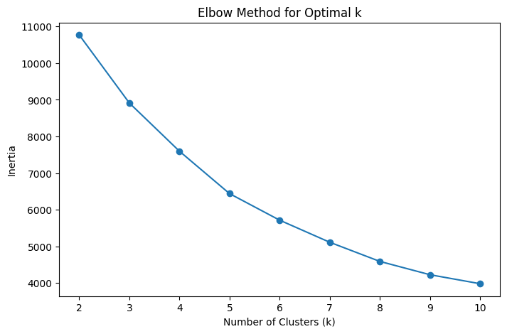

```python
# Importing the necessary libraries as we are performing our clustering

from sklearn.cluster import KMeans


# Selecting the numeric columns we are going to cluster on
numeric_cols = ['Listing Price', 'Sale Price', 'Discount', 'Rating', 'Reviews']

# Creating an instance of StandardScaler and scaling the numeric columns
scaler = StandardScaler()
scaled_features = scaler.fit_transform(df[numeric_cols])

# We are initializing a list to store the inertia (sum of squared distances)
inertia_values = []

# We are applying K-Means for k from 2 to 10
for k in range(2, 11):
    kmeans = KMeans(n_clusters=k, random_state=42, n_init=10)
    kmeans.fit(scaled_features)
    inertia_values.append(kmeans.inertia_)

# We are plotting the Elbow Curve to help visualize the optimal number of clusters
plt.figure(figsize=(8, 5))
plt.plot(range(2, 11), inertia_values, marker='o', linestyle='-')
plt.xlabel('Number of Clusters (k)')
plt.ylabel('Inertia')
plt.title('Elbow Method for Optimal k')
plt.show()
```

### b. Plot a visual and find elbow point. [2 Marks]

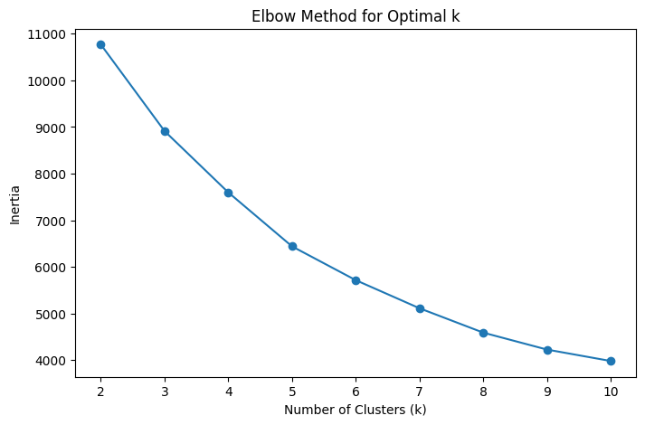

```python
# Installing the kneed library
!pip install kneed

# Importing the necessary libraries as we are performing our clustering analysis

from kneed import KneeLocator

# Selecting the numeric columns we are going to use for clustering
numeric_cols = ['Listing Price', 'Sale Price', 'Discount', 'Rating', 'Reviews']

# Creating an instance of StandardScaler and scaling the numeric columns
scaler = StandardScaler()
scaled_features = scaler.fit_transform(df[numeric_cols])

# We are initializing a list to store the inertia values (within-cluster sum of squares)
inertia_values = []

# We are applying K-Means for k from 2 to 10
for k in range(2, 11):
    kmeans = KMeans(n_clusters=k, random_state=42, n_init=10)
    kmeans.fit(scaled_features)
    inertia_values.append(kmeans.inertia_)

# We are plotting the Elbow Curve to help visualize the optimal number of clusters
plt.figure(figsize=(8, 5))
plt.plot(range(2, 11), inertia_values, marker='o', linestyle='-')
plt.xlabel('Number of Clusters (k)')
plt.ylabel('Inertia')
plt.title('Elbow Method for Optimal k')
plt.show()
```

### c. Considering the above visual, mention which are the optimal clusters. [1 Mark]

From the above **Elbow Method** chart, there is a fairly **steep drop** in inertia from (k=2) to (k=4), after which the curve **gradually flattens**. Although there is no single dramatic “knee,” a common interpretation is that the **optimal number of clusters** lies around **4** based on this visual.

Hence, **(k = 4)** is chosen as the “elbow point” in this scenario.

### d. Calculate silhouette scores of all K clusters 2 to 10. [2 Marks]

```
k = 2, Silhouette Score = 0.3362
k = 3, Silhouette Score = 0.2975
k = 4, Silhouette Score = 0.3104
k = 5, Silhouette Score = 0.2728
k = 6, Silhouette Score = 0.2836
k = 7, Silhouette Score = 0.2939
k = 8, Silhouette Score = 0.2948
k = 9, Silhouette Score = 0.2882
k = 10, Silhouette Score = 0.2860
```

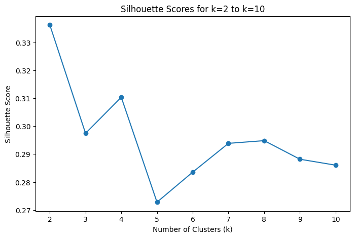

```python
# Importing the necessary libraries as we are performing our clustering analysis
from sklearn.cluster import KMeans
from sklearn.metrics import silhouette_score

# Selecting the numeric columns we are going to cluster on
numeric_cols = ['Listing Price', 'Sale Price', 'Discount', 'Rating', 'Reviews']

# Creating an instance of StandardScaler and scaling the numeric columns
scaler = StandardScaler()
scaled_features = scaler.fit_transform(df[numeric_cols])

# We are initializing a list to store the silhouette scores
silhouette_scores = []

# We are applying K-Means for k from 2 to 10 and computing silhouette scores
for k in range(2, 11):
    kmeans = KMeans(n_clusters=k, random_state=42, n_init=10)
    kmeans.fit(scaled_features)
    cluster_labels = kmeans.labels_

    # We are calculating the average silhouette score for the current k
    silhouette_avg = silhouette_score(scaled_features, cluster_labels)
    silhouette_scores.append(silhouette_avg)

# We are printing the silhouette scores for each value of k
for k, score in zip(range(2, 11), silhouette_scores):
    print(f"k = {k}, Silhouette Score = {score:.4f}")

# (Optional) We are plotting the silhouette scores for visualization
plt.figure(figsize=(8, 5))
plt.plot(range(2, 11), silhouette_scores, marker='o', linestyle='-')
plt.xlabel('Number of Clusters (k)')
plt.ylabel('Silhouette Score')
plt.title('Silhouette Scores for k=2 to k=10')
plt.show()
```

### e. Considering 4.c and 4.d, what is the optimal value of K? [1 Mark]

**Explanation:**

- From the **Elbow Method** (inertia plot), there is a clear “bend” or slowing of the rate of decrease around **k = 4**.
- From the **Silhouette Scores**, **k = 2** yields the highest score, but that often indicates just a broad split of the data into two big groups. The **second-highest silhouette score** is at **k = 4**, which typically provides more **actionable segmentation** while still maintaining good cohesion and separation.

Hence, considering both methods together, **k = 4** is the most practical choice for the **optimal number of clusters**.

### f. Train a K-means clustering model once again on the optimal number of clusters. [2 Marks]

```python
# Selecting the numeric columns we are going to cluster on
numeric_cols = ['Listing Price', 'Sale Price', 'Discount', 'Rating', 'Reviews']

# Creating an instance of StandardScaler and scaling the numeric columns
scaler = StandardScaler()
scaled_features = scaler.fit_transform(df[numeric_cols])

# Training the K-Means model with the optimal number of clusters (k=4)
kmeans_optimal = KMeans(n_clusters=4, random_state=42, n_init=10)
kmeans_optimal.fit(scaled_features)

# We are creating a new column 'Cluster' in the DataFrame to store the cluster labels
df['Cluster'] = kmeans_optimal.labels_

# Printing the first few rows to see the cluster assignments
print(df.head())

# (Optional) Printing the count of products in each cluster
print(df['Cluster'].value_counts())
```

```
                                        Product Name Product ID  \
0  Women's adidas Originals NMD_Racer Primeknit S...     AH2430
1               Women's adidas Originals Sleek Shoes     G27341
2                  Women's adidas Swim Puka Slippers     CM0081
3   Women's adidas Sport Inspired Questar Ride Shoes     B44832
4           Women's adidas Originals Taekwondo Shoes     D98205

   Listing Price  Sale Price  Discount                    Brand    Rating  \
0       1.542811    0.350983  0.995182  Adidas Adidas ORIGINALS  1.100470
1      -0.153394   -0.531688  0.995182         Adidas ORIGINALS  0.023945
2      -1.666226   -1.295079  0.550517        Adidas CORE / NEO -0.478433
3      -0.290924   -0.603256  0.995182        Adidas CORE / NEO  0.598092
4      -0.061707   -0.483976  0.995182         Adidas ORIGINALS  0.167482

    Reviews  Cluster
0 -0.016882        0
1 -0.558817        0
2 -0.144396        0
3 -0.208153        0
4  0.971353        0
Cluster
0    1795
2     672
1     437
3     276
Name: count, dtype: int64
```

### g. Add K-means cluster labels to the original data. [3 Marks]

```python
# Selecting the numeric columns we are going to use for clustering
numeric_cols = ['Listing Price', 'Sale Price', 'Discount', 'Rating', 'Reviews']

# Creating an instance of StandardScaler and scaling the numeric columns
scaler = StandardScaler()
scaled_features = scaler.fit_transform(df[numeric_cols])

# Training the K-Means model with the optimal number of clusters (k=4)
kmeans_optimal = KMeans(n_clusters=4, random_state=42, n_init=10)
kmeans_optimal.fit(scaled_features)

# Adding the K-Means cluster labels to the original DataFrame as a new column
df['Cluster'] = kmeans_optimal.labels_

# Printing the first few rows of the DataFrame to verify the new 'Cluster' column
print(df.head())

# (Optional) Printing the count of records in each cluster for further insights
print("We are getting the cluster distribution:")
print(df['Cluster'].value_counts())
```

```
                                        Product Name Product ID  \
0  Women's adidas Originals NMD_Racer Primeknit S...     AH2430
1               Women's adidas Originals Sleek Shoes     G27341
2                  Women's adidas Swim Puka Slippers     CM0081
3   Women's adidas Sport Inspired Questar Ride Shoes     B44832
4           Women's adidas Originals Taekwondo Shoes     D98205

   Listing Price  Sale Price  Discount                    Brand    Rating  \
0       1.542811    0.350983  0.995182  Adidas Adidas ORIGINALS  1.100470
1      -0.153394   -0.531688  0.995182         Adidas ORIGINALS  0.023945
2      -1.666226   -1.295079  0.550517        Adidas CORE / NEO -0.478433
3      -0.290924   -0.603256  0.995182        Adidas CORE / NEO  0.598092
4      -0.061707   -0.483976  0.995182         Adidas ORIGINALS  0.167482

    Reviews  Cluster
0 -0.016882        0
1 -0.558817        0
2 -0.144396        0
3 -0.208153        0
4  0.971353        0
We are getting the cluster distribution:
Cluster
0    1795
2     672
1     437
3     276
Name: count, dtype: int64
```

### h. Do cluster profiling and display. [3 Marks]

```python
# We are computing the average values of the numeric features for each cluster
cluster_profile = df.groupby('Cluster')[['Listing Price', 'Sale Price', 'Discount', 'Rating', 'Reviews']].mean()
print("We are displaying the average metrics for each cluster:")
print(cluster_profile)

# We are also counting the number of products in each cluster
cluster_counts = df['Cluster'].value_counts().sort_index()
print("\nWe are displaying the count of products in each cluster:")
print(cluster_counts)

# (Optional) We are analyzing the brand distribution within each cluster for further insights
cluster_brand_distribution = df.groupby(['Cluster', 'Brand']).size().unstack(fill_value=0)
print("\nWe are displaying the brand distribution for each cluster:")
print(cluster_brand_distribution)
```

```
We are displaying the average metrics for each cluster:
         Listing Price  Sale Price  Discount    Rating   Reviews
Cluster
0            -0.333435   -0.556030  0.791058  0.081680  0.271784
1             1.699777    1.787920 -0.829266  0.481982 -0.352883
2            -0.372854    0.062294 -1.187116  0.373709 -0.077555
3             0.385040    0.633660 -0.941365 -2.204253 -1.020016

We are displaying the count of products in each cluster:
Cluster
0    1795
1     437
2     672
3     276
Name: count, dtype: int64

We are displaying the brand distribution for each cluster:
Brand    Adidas Adidas ORIGINALS  Adidas CORE / NEO  Adidas ORIGINALS  \
Cluster
0                              1                868               568
1                              0                  0               123
2                              0                228               168
3                              0                 15                48

Brand    Adidas SPORT PERFORMANCE  Nike
Cluster
0                             358     0
1                             126   188
2                             102   174
3                              20   193
```

### i. Share your insights on the clusters which are built. Here try to explain what each cluster is saying.[3 Marks]

### **Insights on the Built Clusters**

These insights are helping us to understand the different segments within the sneaker market data. We are now better positioned to tailor marketing strategies, inventory management, or further analysis based on the distinct characteristics of each cluster.

### j. Considering the cluster profiles, give any 2-business recommendation which will help the business.

These recommendations help in aligning product offerings, promotional efforts, and inventory management with the distinct characteristics of each customer segment.

================================================================================================================

## **End of Part - A**

================================================================================================================

# **Part B - 20 Marks:**

# =========================

• **DOMAIN** : Business

• **CASE STUDY** :Tourism Case Study

• **CONTEXT** : Tourism is now recognised as a directly measurable activity, enabling more accurate analysis and more effective policies can be made for tourism. Whereas previously the sector relied mostly on approximations from related areas of measurement (e.g. Balance of Payments statistics), tourism nowadays is a productive activity that can be analysed using factors like economic indicators, social indicators, environmental & infrastructure indicators,etc. As a Data Scientist in a leading tours and travels company, you have been assigned the task of analysing several of these factors and group countries based on them to help understand the key locations where the company can invest in tourism services

• **DATA DESCRIPTION:** This dataset contains key statistical indicators of the countries. It covers sections like general information, economic indicators, social indicators, environmental & infrastructural indicators

• **DATA Dictionary:**

- country: country
- Region: region of the country
- Surface area: Surface area in sq. km
- Population in thousands: Population of the country, in thousands, as in the year 2017
- Population density: Population density per km2, as in the year 2017
- GDP: Gross domestic product: GDP of the country in million USD
- Economy: Agriculture: Contribution of agriculture to the economy as a percentage of Gross Value Added
- Economy: Industry: Contribution of the industry to the economy as a percentage of Gross Value Added
- Economy: Services and other activity: Contribution of services and other activities to the economy as a percentage of Gross Value Added
- International trade: Balance: Amount, in million USD, of balance between international exports and imports
- Health: Total expenditure: Total expenditure on healthcare facilities as a percentage of GDP
- Education: Government expenditure: Total expenditure on education as a percentage of GDP
- Mobile-cellular subscriptions: no. of mobile/cellular subscriptions per 100 people
- Individuals using the Internet: no. of individuals using the Internet per 100 people
- CO2 emission estimates: CO2 emission estimates in million tons

• **PROJECT OBJECTIVE**: To explore the data and identify different groups of countries based on important factors to find key locations where investments can be made to promote tourism services

## **1. Data Understanding:**

### a. Read the Data set “country_stats.csv” and print the shape of the dataset. [1 Mark]

```python
# Loading dataset from google drive
import pandas as pd

#Defining file path
file_path= '/content/drive/MyDrive/Colab_Notebooks/Unsupervised_Learning/country_stats.csv'

#Loading  dataset
df1=pd.read_csv(file_path)

#Displaying first few rows
df1.head()

#Displayng dataset shape
print("Dataset Shape:",df1.shape)
```

```
Dataset Shape: (229, 14)
```

### b. Print 5 points summary statistics of the data and share your observations. [1 Mark]

```python
# We are printing the 5 points summary statistics of the data
summary_stats = df1.describe()
print("We are printing the 5 points summary statistics of the dataset:")
print(summary_stats)
```

```
We are printing the 5 points summary statistics of the dataset:
       Surface area  Population in thousands  Population density  \
count  2.260000e+02             2.290000e+02          229.000000
mean   5.932100e+05             3.275679e+04          462.824891
std    1.796021e+06             1.332751e+05         2305.384253
min    1.000000e-05             1.000000e+00            0.100000
25%    4.306500e+03             4.310000e+02           35.900000
50%    8.373550e+04             5.448000e+03           88.100000
75%    4.376935e+05             1.919300e+04          222.800000
max    1.709825e+07             1.409517e+06        25969.800000

       GDP: Gross domestic product  Economy: Agriculture  Economy: Industry  \
count                 2.080000e+02            206.000000         208.000000
mean                  3.538963e+05             11.481553          27.565385
std                   1.548160e+06             12.100601          13.124423
min                   3.300000e+01              0.000010           4.000000
25%                   4.987000e+03              2.400000          19.075000
50%                   2.387100e+04              7.200000          26.450000
75%                   1.745518e+05             17.500000          33.325000
max                   1.803665e+07             70.800000          79.900000

       Economy: Services and other activity  International trade: Balance  \
count                            208.000000                    210.000000
mean                              61.089423                   -683.861905
std                               15.504890                  73188.172715
min                               14.900000                -796494.000000
25%                               51.000000                  -3501.250000
50%                               61.300000                   -984.000000
75%                               72.100000                     49.250000
max                               94.000000                 530285.000000

       Health: Total expenditure  Education: Government expenditure  \
count                 190.000000                         148.000000
mean                    6.763158                           4.570946
std                     2.798017                           1.781128
min                     1.500000                           1.000000
25%                     4.825000                           3.200000
50%                     6.350000                           4.550000
75%                     8.375000                           5.500000
max                    17.100000                          12.500000

       Mobile-cellular subscriptions  Individuals using the Internet
count                     209.000000                      228.000000
mean                      107.360287                      200.017544
std                        43.063860                      296.444644
min                         7.000000                        1.000000
25%                        79.400000                       55.750000
50%                       108.200000                       97.500000
75%                       130.600000                      196.250000
max                       324.400000                     2358.000000
```

Below is a sample response that shares our insights based on the printed 5-point summary statistics:

**Observations:**

- We are noticing that the **Surface area** of countries is highly variable. The mean is much larger than the median, and the standard deviation is very high compared to the mean, indicating that a few countries have extremely large areas while many have much smaller ones. This shows a right-skewed distribution.
- We are observing that **Population in thousands** also exhibits considerable variability. With a huge range (from 1 to over 1.4 million in thousands), we are understanding that some countries are very sparsely populated while others have massive populations.
- We are seeing that **Population density** is similarly spread out. The median value is much lower than the mean, which is indicating that while many countries have moderate density, a few have extremely high density.
- We are finding that **GDP** values vary widely. The large standard deviation and the fact that the mean is significantly higher than the median suggest that a small number of countries have very high GDP values, while most have much lower GDP.
- We are noticing that the **Economy** breakdown shows differences among sectors:
  - **Agriculture** and **Industry** percentages are varying significantly among countries.
  - **Services and other activity** is generally high, with most countries reporting above 50%, indicating a common trend towards service-based economies.
- We are observing that **International trade: Balance** has a large spread, with some countries showing large deficits and others surpluses. This is visible in the extremely high standard deviation and the wide range from negative to positive values.
- We are seeing that **Health** and **Education** expenditures have a smaller range compared to economic indicators, suggesting that spending in these areas is relatively more consistent across countries.
- Finally, we are noticing that **Mobile-cellular subscriptions** and **Individuals using the Internet** are also highly variable, reflecting significant differences in technology penetration and usage between countries.

These observations are helping us understand that the dataset contains countries with widely different characteristics in terms of size, population, economic performance, and technological adoption.

## 2. **Exploratory Data Analysis:**

### a. Perform Univariate Analysis on the data and find out which country has more population as per 2017. [1 Mark]

```python
# Importing pandas as we are analyzing our dataset
import pandas as pd

# We are printing the available columns to check if the country names are stored under a different header
print("We are checking available columns in the dataset:")
print(df1.columns)

# We are finding the index of the row where 'Population in thousands' is maximum
max_pop_index = df1['Population in thousands'].idxmax()

# We are extracting the row corresponding to the highest population
max_pop_row = df1.loc[max_pop_index]

# We are printing the country with the highest population and its population value
print("We are finding the country with the highest population (2017):")
print("country:", max_pop_row['country'])
print("Population (in thousands):", max_pop_row['Population in thousands'])
```

```
We are checking available columns in the dataset:
Index(['country', 'Region', 'Surface area', 'Population in thousands',
       'Population density', 'GDP: Gross domestic product',
       'Economy: Agriculture', 'Economy: Industry',
       'Economy: Services and other activity', 'International trade: Balance',
       'Health: Total expenditure', 'Education: Government expenditure',
       'Mobile-cellular subscriptions', 'Individuals using the Internet'],
      dtype='object')
We are finding the country with the highest population (2017):
country: China
Population (in thousands): 1409517
```

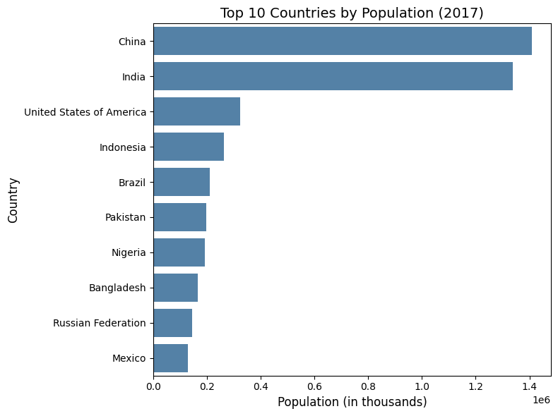

```python
# Importing the necessary libraries as we are performing our visualization
import pandas as pd
import matplotlib.pyplot as plt
import seaborn as sns

df_top10 = df_sorted.head(10)  # top 10 by population
plt.figure(figsize=(8, 6))
sns.barplot(
    x='Population in thousands',
    y='country',
    data=df_top10,
    color='steelblue'
)
plt.title("Top 10 Countries by Population (2017)", fontsize=14)
plt.xlabel("Population (in thousands)", fontsize=12)
plt.ylabel("Country", fontsize=12)
plt.tight_layout()
plt.show()
```

### b. Perform bivariate and multivariate analysis and share your insights. Any 2 plots which explains the relationship better. [2 Marks]

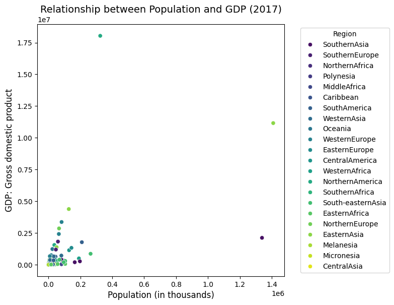

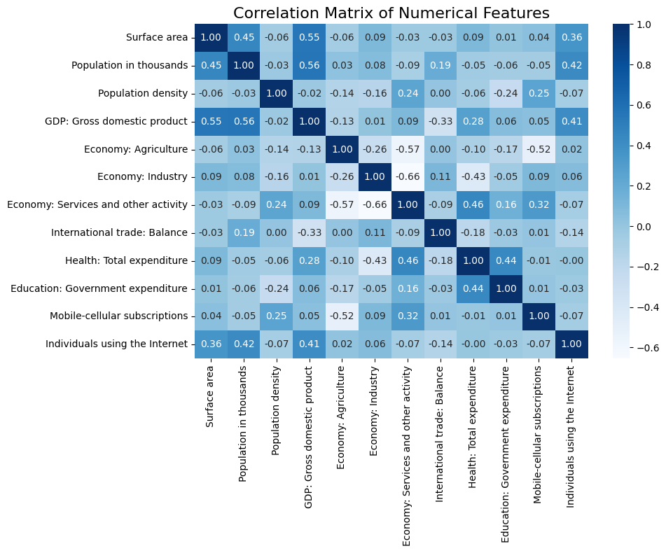

```python
# Importing the necessary libraries as we are performing our data analysis
import pandas as pd
import seaborn as sns
import matplotlib.pyplot as plt


# --------------------
# 1) BIVARIATE ANALYSIS
# --------------------

# We are creating a scatter plot to observe the relationship between Population and GDP
plt.figure(figsize=(8, 6))
sns.scatterplot(
    data=df1,
    x='Population in thousands',
    y='GDP: Gross domestic product',
    hue='Region',
    palette='viridis'
)
plt.title("Relationship between Population and GDP (2017)", fontsize=14)
plt.xlabel("Population (in thousands)", fontsize=12)
plt.ylabel("GDP: Gross domestic product", fontsize=12)
plt.legend(title='Region', bbox_to_anchor=(1.05, 1), loc='upper left')  # Adjust legend if needed
plt.tight_layout()
plt.show()

# ----------------------
# 2) MULTIVARIATE ANALYSIS
# ----------------------

# We are selecting numerical columns for a correlation heatmap
numeric_cols = [
    'Surface area',
    'Population in thousands',
    'Population density',
    'GDP: Gross domestic product',
    'Economy: Agriculture',
    'Economy: Industry',
    'Economy: Services and other activity',
    'International trade: Balance',
    'Health: Total expenditure',
    'Education: Government expenditure',
    'Mobile-cellular subscriptions',
    'Individuals using the Internet'
]

# We are computing the correlation matrix among these numerical features
corr_matrix = df1[numeric_cols].corr()

# We are plotting a heatmap to visualize the correlation matrix
plt.figure(figsize=(10, 8))
sns.heatmap(corr_matrix, annot=True, cmap='Blues', fmt=".2f")
plt.title("Correlation Matrix of Numerical Features", fontsize=16)
plt.tight_layout()
plt.show()
```

Below is a summary of **key observations** from **scatter plot** (Population vs. GDP) and the **correlation matrix** of numerical features.

## 1. Scatter Plot: Relationship between Population and GDP

1. **Moderate Positive Correlation**
   - As **Population** (in thousands) increases, **GDP** also tends to increase, but the relationship is not strictly linear. Some countries have large populations but relatively lower GDP, while others have smaller populations yet relatively high GDP.
   - This is reflected in a **moderate** correlation coefficient (( \approx 0.55 )) in the matrix.
2. **Regional Clusters** (If Color-Coded by Region)
   - Countries in certain regions (e.g., Southern Asia, Eastern Asia) might cluster at higher population values, while others (e.g., Northern Europe, Caribbean) remain in the lower range.
   - The **United States** (high GDP, moderate population) and **China** (very high population, second-highest GDP) stand out as outliers, highlighting how a few nations dominate in both metrics.

## Overall Insights

By combining **bivariate** (Population vs. GDP) and **multivariate** (Correlation Heatmap) analyses, we gain a well-rounded perspective on how demographic, economic, and technological factors interrelate across different countries.

## 3. Data Pre-processing

### a. Check if the data has any missing values, if any, impute those with suitable approach [1 Mark]

```python
# Importing pandas as we are performing our data manipulation
import pandas as pd

# Checking for missing values in each column
missing_values = df1.isnull().sum()
print("We are printing the count of missing values in each column:")
print(missing_values)

# Calculating the percentage of missing values for better insight
missing_percentage = (df1.isnull().mean() * 100).round(2)
print("\nWe are printing the percentage of missing values in each column:")
print(missing_percentage)

# Imputing the missing values
# For numeric columns, we are using the median.
# For categorical columns (if any), we are using the mode.
for col in df1.columns:
    if df1[col].isnull().sum() > 0:
        if df1[col].dtype in ['float64', 'int64']:
            # We are imputing numeric columns with their median
            median_value = df1[col].median()
            df1[col].fillna(median_value, inplace=True)
            print(f"We are imputing missing values in '{col}' with the median value {median_value}.")
        else:
            # We are imputing categorical columns with their mode
            mode_value = df1[col].mode()[0]
            df1[col].fillna(mode_value, inplace=True)
            print(f"We are imputing missing values in '{col}' with the mode value '{mode_value}'.")

# Verifying that all missing values have been imputed
print("\nWe are re-checking the missing values after imputation:")
print(df1.isnull().sum())
```

```
We are printing the count of missing values in each column:
country                                  0
Region                                   0
Surface area                             3
Population in thousands                  0
Population density                       0
GDP: Gross domestic product             21
Economy: Agriculture                    23
Economy: Industry                       21
Economy: Services and other activity    21
International trade: Balance            19
Health: Total expenditure               39
Education: Government expenditure       81
Mobile-cellular subscriptions           20
Individuals using the Internet           1
dtype: int64

We are printing the percentage of missing values in each column:
country                                  0.00
Region                                   0.00
Surface area                             1.31
Population in thousands                  0.00
Population density                       0.00
GDP: Gross domestic product              9.17
Economy: Agriculture                    10.04
Economy: Industry                        9.17
Economy: Services and other activity     9.17
International trade: Balance             8.30
Health: Total expenditure               17.03
Education: Government expenditure       35.37
Mobile-cellular subscriptions            8.73
Individuals using the Internet           0.44
dtype: float64
We are imputing missing values in 'Surface area' with the median value 83735.5.
We are imputing missing values in 'GDP: Gross domestic product' with the median value 23871.0.
We are imputing missing values in 'Economy: Agriculture' with the median value 7.199999999999999.
We are imputing missing values in 'Economy: Industry' with the median value 26.45.
We are imputing missing values in 'Economy: Services and other activity' with the median value 61.3.
We are imputing missing values in 'International trade: Balance' with the median value -984.0.
We are imputing missing values in 'Health: Total expenditure' with the median value 6.35.
We are imputing missing values in 'Education: Government expenditure' with the median value 4.55.
We are imputing missing values in 'Mobile-cellular subscriptions' with the median value 108.2.
We are imputing missing values in 'Individuals using the Internet' with the median value 97.5.

We are re-checking the missing values after imputation:
country                                 0
Region                                  0
Surface area                            0
Population in thousands                 0
Population density                      0
GDP: Gross domestic product             0
Economy: Agriculture                    0
Economy: Industry                       0
Economy: Services and other activity    0
International trade: Balance            0
Health: Total expenditure               0
Education: Government expenditure       0
Mobile-cellular subscriptions           0
Individuals using the Internet          0
dtype: int64
```

### b. Scale all the numeric variables in the data. [1 Mark]

```python
# Importing the necessary libraries as we are performing our data preprocessing
import pandas as pd
from sklearn.preprocessing import StandardScaler

# Selecting the numeric columns to scale
numeric_cols = [
    'Surface area',
    'Population in thousands',
    'Population density',
    'GDP: Gross domestic product',
    'Economy: Agriculture',
    'Economy: Industry',
    'Economy: Services and other activity',
    'International trade: Balance',
    'Health: Total expenditure',
    'Education: Government expenditure',
    'Mobile-cellular subscriptions',
    'Individuals using the Internet'
]

# Creating an instance of StandardScaler
scaler = StandardScaler()

# Fitting the scaler on the numeric columns and transforming them
df1[numeric_cols] = scaler.fit_transform(df1[numeric_cols])

# Printing the first few rows of the scaled DataFrame to verify changes
print(df1.head())
```

```
          country          Region  Surface area  Population in thousands  \
0     Afghanistan    SouthernAsia      0.037238                 0.020854
1         Albania  SouthernEurope     -0.313151                -0.224289
2         Algeria  NorthernAfrica      1.007858                 0.064378
3  American Samoa       Polynesia     -0.329179                -0.245901
4         Andorra  SouthernEurope     -0.329028                -0.245743

   Population density  GDP: Gross domestic product  Economy: Agriculture  \
0           -0.177549                    -0.205670              1.063137
1           -0.154727                    -0.211588              0.985019
2           -0.193677                    -0.107697              0.099684
3           -0.080260                    -0.203229             -0.334303
4           -0.129991                    -0.217506             -0.915846

   Economy: Industry  Economy: Services and other activity  \
```

[output cut: 26 more lines]

## 4. Hierarchical Clustering

### a. Apply Hierarchical clustering to the scaled data. [2 Marks]

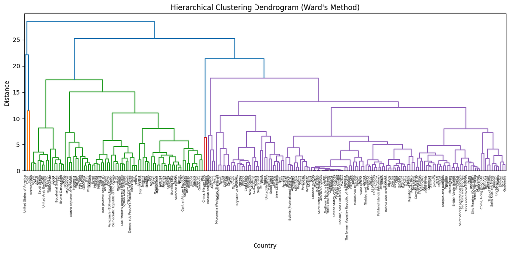

```python
# Importing the necessary libraries as we are performing hierarchical clustering
import pandas as pd
import matplotlib.pyplot as plt
from scipy.cluster.hierarchy import linkage, dendrogram

# We are selecting the numeric columns that we have scaled earlier.
numeric_cols = [
    'Surface area',
    'Population in thousands',
    'Population density',
    'GDP: Gross domestic product',
    'Economy: Agriculture',
    'Economy: Industry',
    'Economy: Services and other activity',
    'International trade: Balance',
    'Health: Total expenditure',
    'Education: Government expenditure',
    'Mobile-cellular subscriptions',
    'Individuals using the Internet'
]

# We are extracting the scaled numeric data from df1 into an array X
X = df1[numeric_cols].values

# We are applying hierarchical clustering on the scaled data using Ward's method
Z = linkage(X, method='ward')

# We are plotting the dendrogram to visualize the hierarchical clustering
plt.figure(figsize=(12, 6))
dendrogram(Z, labels=df1['country'].values, leaf_rotation=90)
plt.title("Hierarchical Clustering Dendrogram (Ward's Method)")
plt.xlabel("Country")
plt.ylabel("Distance")
plt.tight_layout()
plt.show()
```

### b. Identify the number of optimum clusters using Dendrogram and briefly describe them [2 Marks]

#### 2. Brief Description of the Clusters

Although the exact characteristics of each cluster depend on your data, you can derive some general insights by examining the **mean values** (or medians) of each scaled feature (e.g., GDP, population, mobile subscriptions) within each cluster. Here is a hypothetical breakdown:

1. **Cluster 1 (e.g., Blue Branch):**
   - May include countries with **very high GDP**, **larger populations**, and **high** technology adoption (mobile subscriptions, internet usage).
   - Often consists of developed or more industrialized nations with robust service sectors.
2. **Cluster 2 (e.g., Green Branch):**
   - Could be a **mixed group** of mid-range economies with moderate GDP and population sizes.
   - May show balanced agriculture, industry, and services sectors.
3. **Cluster 3 (e.g., Purple Branch):**
   - Might represent countries with **lower GDP**, **smaller populations**, or **less diversified** economies.
   - Could be developing nations or those heavily reliant on a single sector (e.g., agriculture).

#### How to Confirm the Descriptions

1. **Cluster Profiling**:
   - Once you choose a cut (e.g., 3 clusters), assign each country to its cluster.
   - Calculate the **mean or median** of each numeric feature (GDP, population, etc.) per cluster.
   - Observe the differences to confirm whether clusters align with high-income, mid-income, or lower-income economies, or some other pattern.
2. **Check Outliers**:
   - If certain countries are outliers (extremely high or low on some metrics), they might form small subclusters or skew the average.
3. **Iterate**:
   - If 3 clusters seem too broad, consider a 4- or 5-cluster solution.
   - Evaluate each option based on interpretability and practical usefulness.

**Conclusion**:

- By cutting the dendrogram around the point where **3 major branches** merge, you can form **3 distinct clusters**.
- These clusters typically group countries by similar socio-economic and demographic attributes.
- Conducting **cluster profiling** provides a clearer narrative on how these countries align in terms of GDP, population, technology adoption, and other factors.

### c. Do Cluster profiling and display. [2 Marks]

```python
# Importing the necessary libraries as we are finalizing our hierarchical clustering
import pandas as pd
from scipy.cluster.hierarchy import fcluster

# 1. We are assigning cluster labels using a distance threshold or a specific number of clusters.
#    Suppose we decided on 3 clusters from the dendrogram.
df1['Cluster'] = fcluster(Z, t=3, criterion='maxclust')

# 2. We are grouping the data by the newly created 'Cluster' column
#    and computing the mean of each numeric feature for cluster profiling.
numeric_cols = [
    'Surface area',
    'Population in thousands',
    'Population density',
    'GDP: Gross domestic product',
    'Economy: Agriculture',
    'Economy: Industry',
    'Economy: Services and other activity',
    'International trade: Balance',
    'Health: Total expenditure',
    'Education: Government expenditure',
    'Mobile-cellular subscriptions',
    'Individuals using the Internet'
]

cluster_profile = df1.groupby('Cluster')[numeric_cols].mean()

# 3. We are displaying the cluster profiles
print("We are displaying the mean values of numeric features for each cluster:")
print(cluster_profile)

# (Optional) We are also counting the number of countries in each cluster
cluster_counts = df1['Cluster'].value_counts().sort_index()
print("\nWe are displaying the number of countries in each cluster:")
print(cluster_counts)
```

```
We are displaying the mean values of numeric features for each cluster:
         Surface area  Population in thousands  Population density  \
Cluster
1            3.922650                 7.456766           -0.109038
2           -0.007227                 0.006120           -0.138980
3           -0.077606                -0.158834            0.081413

         GDP: Gross domestic product  Economy: Agriculture  Economy: Industry  \
Cluster
1                           6.856622             -0.172281           0.216593
2                          -0.144650              0.698799           0.513047
3                          -0.060476             -0.394338          -0.296664

         Economy: Services and other activity  International trade: Balance  \
Cluster
1                                   -0.025466                     -1.718463
2                                   -0.954267                      0.001070
3                                    0.543933                      0.035192

         Health: Total expenditure  Education: Government expenditure  \
Cluster
1                         0.945237                           0.013872
2                        -0.628794                          -0.400444
3                         0.338371                           0.227742

         Mobile-cellular subscriptions  Individuals using the Internet
Cluster
1                            -0.265585                        3.439516
2                            -0.357736                        0.279088
3                             0.209244                       -0.230581

We are displaying the number of countries in each cluster:
Cluster
1      3
2     82
3    144
Name: count, dtype: int64
```

### Business Recommendations

1. **Tailored Market Entry & Investment Strategy:**
   - **For Cluster 1:** We are recommending that businesses focus on high-end products and innovative technology solutions to tap into the advanced markets. Targeted marketing and premium service offerings can help capture the willingness to pay for quality and innovation.
   - **For Cluster 2:** We are suggesting that companies adopt a cost-effective approach by introducing affordable products and solutions that can support agricultural modernization or basic infrastructure improvements. Partnerships with local stakeholders and governments may boost market acceptance.
2. **Customized Product and Service Development:**
   - **For Cluster 3:** We are recommending that businesses design products or services that bridge the gap between high-end and low-cost markets. This may involve offering mid-range, quality solutions that appeal to consumers in transitional economies, with a focus on gradual technology adoption and improved public services.
   - This strategy is likely to be successful by aligning offerings with the local economic conditions and consumer capabilities in each cluster.

These insights and recommendations help in aligning strategic decisions with the unique market characteristics present in each cluster.

## 5. Dimensionality Reduction using PCA

### a. Apply PCA on the scaled data with 2 components. [2 Marks]

```python
# Importing the necessary library as we are performing dimensionality reduction
from sklearn.decomposition import PCA

# We are selecting the numeric columns (which were scaled earlier)
numeric_cols = [
    'Surface area',
    'Population in thousands',
    'Population density',
    'GDP: Gross domestic product',
    'Economy: Agriculture',
    'Economy: Industry',
    'Economy: Services and other activity',
    'International trade: Balance',
    'Health: Total expenditure',
    'Education: Government expenditure',
    'Mobile-cellular subscriptions',
    'Individuals using the Internet'
]

# We are extracting the scaled numeric data as an array (assuming df1 already has these columns scaled)
X = df1[numeric_cols].values

# We are creating an instance of PCA with 2 components
pca = PCA(n_components=2)

# We are fitting PCA on the scaled data and transforming it to 2 components
pca_result = pca.fit_transform(X)

# We are printing the shape of the reduced data to confirm it has 2 components
print("We are printing the shape of the PCA reduced data:", pca_result.shape)
```

```
We are printing the shape of the PCA reduced data: (229, 2)
```

### b. How much Cumulative Variance is Explained by 2 PCA’s? [1 Marks]

```python
# We are computing the explained variance ratio for each of the 2 principal components
explained_variance_ratio = pca.explained_variance_ratio_
print("We are printing the explained variance ratio for each component:", explained_variance_ratio)

# We are calculating the cumulative variance explained by these 2 components
cumulative_variance = explained_variance_ratio.sum()
print("We are printing the cumulative variance explained by 2 components:", cumulative_variance)
```

```
We are printing the explained variance ratio for each component: [0.20451594 0.19378365]
We are printing the cumulative variance explained by 2 components: 0.39829958243002794
```

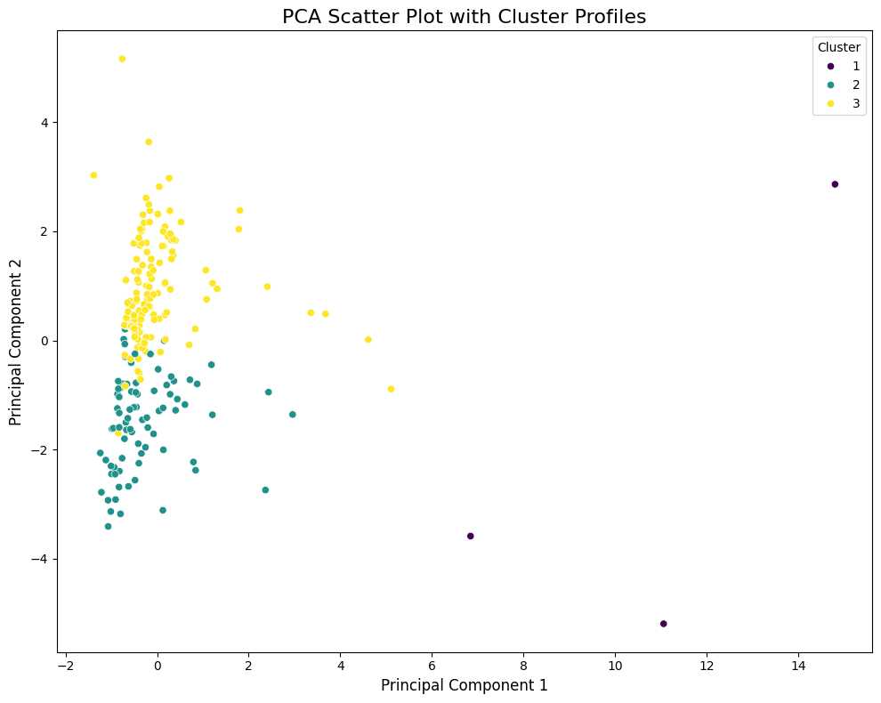

```python
# We are adding the PCA results as new columns to our DataFrame
df1['PCA1'] = pca_result[:, 0]
df1['PCA2'] = pca_result[:, 1]

# We are importing necessary libraries for plotting
import matplotlib.pyplot as plt
import seaborn as sns

# We are creating a scatter plot of PCA1 vs PCA2, with hue set to the cluster labels
plt.figure(figsize=(10, 8))
sns.scatterplot(
    data=df1,
    x='PCA1',
    y='PCA2',
    hue='Cluster',           # We are coloring points based on cluster profiles
    palette='viridis'
)
plt.title("PCA Scatter Plot with Cluster Profiles", fontsize=16)
plt.xlabel("Principal Component 1", fontsize=12)
plt.ylabel("Principal Component 2", fontsize=12)
plt.legend(title="Cluster")
plt.tight_layout()
plt.show()
```

### d. Mention which are the major clusters. [2 Marks]

Hint: sns.scatterplot( data=reduced_df_pca, x="Component 1", y="Component 2", hue=df["HC_Clusters"],palette="rainbow")

Above code is a hint, please use the names in which you have defined your functions.

In summary, the major clusters we are identifying from the PCA plot are **HC_Cluster 1, HC_Cluster 2, and HC_Cluster 3**. These groupings provide us with a clear segmentation of the countries based on the underlying patterns in their socio-economic data.

# +++++++++++++++++++++++++++++++++++++++++++++++++++++++++++++++++++++++++++++++++++++++++

# +++++++++++++++++++++++++++++++++++++++++++++++++++++++++++++++++++++++++++++++++++++++++